# Effect of Sea Star Wasting Disease on Mussel Abundance

Loading the necessary libraries

```r
library(dplyr)
library(ggplot2)
library(gridExtra)
```

Reading in the sea star and mussel data set

```r
abundance_data <- read.csv("data/change in pisaster and mussels PISCO sites.csv")
```

Viewing the entire dataset to get an idea about what it looks like

```r
View(abundance_data)
```

Using ncol and nrow to find out how many variables and values there are

```r
ncol(abundance_data)
```

```
## [1] 16
```

```r
nrow(abundance_data)
```

```
## [1] 33
```

Using glimpse() to get a better view of the columns and their names

```r
glimpse(abundance_data)
```

```
## Rows: 33
## Columns: 16
## $ ï..site                                           <chr> "Alegria", "Andre...
## $ Lat                                               <dbl> 34.46714, 36.2806...
## $ Long                                              <dbl> -120.2782, -121.8...
## $ georegion                                         <chr> "CA South", "CA C...
## $ Mean.percent_cover_Mytcal..pre.SSWS               <dbl> 8.4506761, 0.4792...
## $ Mean.percent_cover_Mytcal..post.SSWS              <dbl> 3.2450897, 3.1881...
## $ Mean.Pisaster.density..pre.SSWS                   <dbl> 0.050250000, 0.08...
## $ Mean.Pisaster.density..post.SSWS                  <dbl> 0.0010, 0.0890, 0...
## $ change_mussel_cover                               <dbl> -5.2055864, 2.708...
## $ change_pisaster_density                           <dbl> -0.049250000, 0.0...
## $ Square.Root.change_mussel_cover.                  <dbl> -2.2815754, 1.645...
## $ Square.Root.change_pisaster_density.              <dbl> -0.22192341, 0.07...
## $ Square.Root.Mean.Pisaster.density..pre.SSWS.      <dbl> 0.22416512, 0.288...
## $ Square.Root.Mean.Pisaster.density..post.SSWS.     <dbl> 0.03162278, 0.298...
## $ Square.Root.Mean.percent_cover_Mytcal..pre.SSWS.  <dbl> 2.9070047, 0.6922...
## $ Square.Root.Mean.percent_cover_Mytcal..post.SSWS. <dbl> 1.8014132, 1.7855...
```

After viewing the data, I have decided I want to manipulate and plot the data of the mean percent mussel cover before and after mass starfish mortality. I feel that this will give me a good idea about how the removal of Pisaster has affected the mussel abundance

In the below code I am renaming the columns to pre_mean_cover and post_mean_cover to make them easier to use in code

```r
abundance_data_v2 <- rename(abundance_data, pre_mean_mussel_cover = Mean.percent_cover_Mytcal..pre.SSWS,post_mean_mussel_cover = Mean.percent_cover_Mytcal..post.SSWS)
```

I am then isolating the two columns I will be using in the graph into their own data frame in order to manipulate them further

```r
mean_mussel_cover_data <- select(abundance_data_v2, c(pre_mean_mussel_cover, post_mean_mussel_cover))
```

In order to create a histogram with the pre and post data overlapping each other I create separate data frames: one consisting of just the pre SSWD percent mussel cover data and on with the post SSWD data. Then I rename the columns in these new, separate data frames to match so I can graph them together. I use the view() function after every change or rename to make sure the code worked properly.

```r
pre_cover_data <- select(abundance_data_v2, c(pre_mean_mussel_cover))

pre_cover_data_v2 <- rename(pre_cover_data, mean_percent_cover = pre_mean_mussel_cover)
```

```r
post_cover_data <-  select(abundance_data_v2, c(post_mean_mussel_cover))

post_cover_data_v2 <- rename(post_cover_data, mean_percent_cover = post_mean_mussel_cover)
```

Finally, I graph the two data frames (pre and post) in a single histogram, making sure they are transparent and a legend is included.

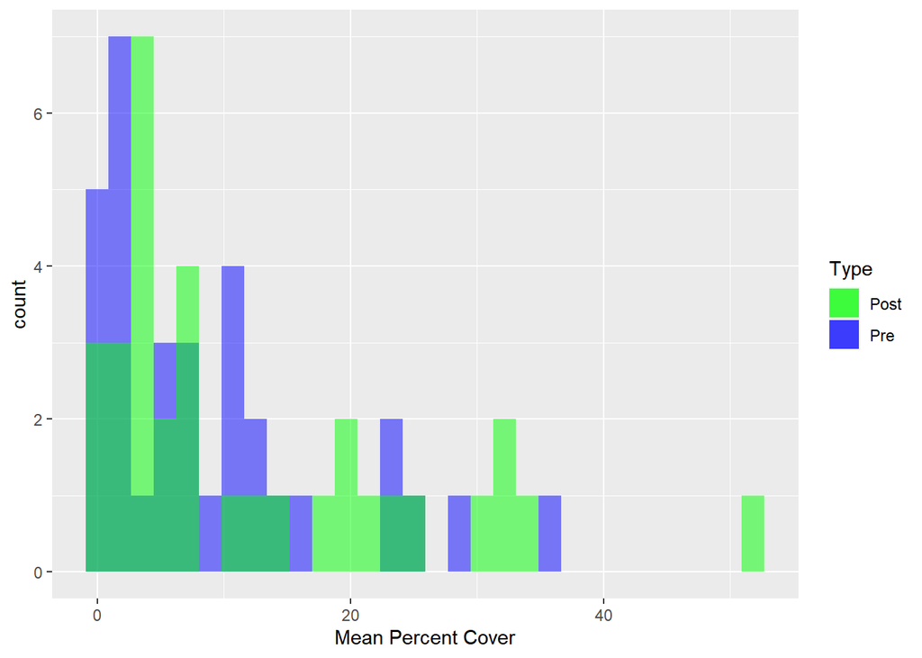

```r
mean_cover_histogram <- rbind(pre_cover_data_v2, post_cover_data_v2)

mean_cover_histogram<- ggplot(mean_cover_histogram) +
  geom_histogram(data=pre_cover_data_v2, aes(x=mean_percent_cover, fill = "Pre"), alpha = 0.5) +
  geom_histogram(data=post_cover_data_v2, aes(x=mean_percent_cover, fill = "Post"), alpha = 0.5) +
  xlab("Mean Percent Cover") +
  scale_fill_manual("Type", values = c(Pre = "blue", Post = "green"))

print(mean_cover_histogram)
```